# MovieLens Project Questions

### `Project - MovieLens Data Analysis`

The GroupLens Research Project is a research group in the Department of Computer Science and Engineering at the University of Minnesota. The data is widely used for collaborative filtering and other filtering solutions. However, we will be using this data to act as a means to demonstrate our skill in using Python to “play” with data.

### `Objective:`

- To implement the techniques learnt as a part of the course.

### `Learning Outcomes:`

- Exploratory Data Analysis
- Visualization using Python
- Pandas – groupby, merging

### `Domain`

- Internet and Entertainment

**Note that the project will need you to apply the concepts of groupby and merging extensively.**

### `Datasets Information:`

*rating.csv:* It contains information on ratings given by the users to a particular movie.

- user id: id assigned to every user
- movie id: id assigned to every movie
- rating: rating given by the user
- timestamp: Time recorded when the user gave a rating

*movie.csv:* File contains information related to the movies and their genre.

- movie id: id assigned to every movie
- movie title: Title of the movie
- release date: Date of release of the movie
- Action: Genre containing binary values (1 - for action 0 - not action)
- Adventure: Genre containing binary values (1 - for adventure 0 - not adventure)
- Animation: Genre containing binary values (1 - for animation 0 - not animation)
- Children’s: Genre containing binary values (1 - for children's 0 - not children's)
- Comedy: Genre containing binary values (1 - for comedy 0 - not comedy)
- Crime: Genre containing binary values (1 - for crime 0 - not crime)
- Documentary: Genre containing binary values (1 - for documentary 0 - not documentary)
- Drama: Genre containing binary values (1 - for drama 0 - not drama)
- Fantasy: Genre containing binary values (1 - for fantasy 0 - not fantasy)
- Film-Noir: Genre containing binary values (1 - for film-noir 0 - not film-noir)
- Horror: Genre containing binary values (1 - for horror 0 - not horror)
- Musical: Genre containing binary values (1 - for musical 0 - not musical)
- Mystery: Genre containing binary values (1 - for mystery 0 - not mystery)
- Romance: Genre containing binary values (1 - for romance 0 - not romance)
- Sci-Fi: Genre containing binary values (1 - for sci-fi 0 - not sci-fi)
- Thriller: Genre containing binary values (1 - for thriller 0 - not thriller)
- War: Genre containing binary values (1 - for war 0 - not war)
- Western: Genre containing binary values (1 - for western - not western)

*user.csv:* It contains information of the users who have rated the movies.

- user id: id assigned to every user
- age: Age of the user
- gender: Gender of the user
- occupation: Occupation of the user
- zip code: Zip code of the use

**`Please provide you insights wherever necessary.`**

### 1. Import the necessary packages - 2.5 marks

```python
import numpy as np
import pandas as pd
import matplotlib.pyplot as plt
import pandas_profiling
```

### 2. Read the 3 datasets into dataframes - 2.5 marks

```python
user_movies_ratings_pd  = pd.read_csv('Data.csv')
movie_details_pd  = pd.read_csv('item.csv')
user_pd  = pd.read_csv('user.csv')
```

```python
user_movies_ratings_pd.head()
```

|  | user id | movie id | rating | timestamp |
| --- | --- | --- | --- | --- |
| 0 | 196 | 242 | 3 | 881250949 |
| 1 | 186 | 302 | 3 | 891717742 |
| 2 | 22 | 377 | 1 | 878887116 |
| 3 | 244 | 51 | 2 | 880606923 |
| 4 | 166 | 346 | 1 | 886397596 |

```python
movie_details_pd
```

|  | movie id | movie title | release date | unknown | Action | Adventure | Animation | Childrens | Comedy | Crime | ... | Fantasy | Film-Noir | Horror | Musical | Mystery | Romance | Sci-Fi | Thriller | War | Western |
| --- | --- | --- | --- | --- | --- | --- | --- | --- | --- | --- | --- | --- | --- | --- | --- | --- | --- | --- | --- | --- | --- |
| 0 | 1 | Toy Story | 01-Jan-1995 | 0 | 0 | 0 | 1 | 1 | 1 | 0 | ... | 0 | 0 | 0 | 0 | 0 | 0 | 0 | 0 | 0 | 0 |
| 1 | 2 | GoldenEye | 01-Jan-1995 | 0 | 1 | 1 | 0 | 0 | 0 | 0 | ... | 0 | 0 | 0 | 0 | 0 | 0 | 0 | 1 | 0 | 0 |
| 2 | 3 | Four Rooms | 01-Jan-1995 | 0 | 0 | 0 | 0 | 0 | 0 | 0 | ... | 0 | 0 | 0 | 0 | 0 | 0 | 0 | 1 | 0 | 0 |
| 3 | 4 | Get Shorty | 01-Jan-1995 | 0 | 1 | 0 | 0 | 0 | 1 | 0 | ... | 0 | 0 | 0 | 0 | 0 | 0 | 0 | 0 | 0 | 0 |
| 4 | 5 | Copycat | 01-Jan-1995 | 0 | 0 | 0 | 0 | 0 | 0 | 1 | ... | 0 | 0 | 0 | 0 | 0 | 0 | 0 | 1 | 0 | 0 |
| ... | ... | ... | ... | ... | ... | ... | ... | ... | ... | ... | ... | ... | ... | ... | ... | ... | ... | ... | ... | ... | ... |
| 1676 | 1678 | Mat' i syn | 06-Feb-1998 | 0 | 0 | 0 | 0 | 0 | 0 | 0 | ... | 0 | 0 | 0 | 0 | 0 | 0 | 0 | 0 | 0 | 0 |
| 1677 | 1679 | B. Monkey | 06-Feb-1998 | 0 | 0 | 0 | 0 | 0 | 0 | 0 | ... | 0 | 0 | 0 | 0 | 0 | 1 | 0 | 1 | 0 | 0 |
| 1678 | 1680 | Sliding Doors | 01-Jan-1998 | 0 | 0 | 0 | 0 | 0 | 0 | 0 | ... | 0 | 0 | 0 | 0 | 0 | 1 | 0 | 0 | 0 | 0 |
| 1679 | 1681 | You So Crazy | 01-Jan-1994 | 0 | 0 | 0 | 0 | 0 | 1 | 0 | ... | 0 | 0 | 0 | 0 | 0 | 0 | 0 | 0 | 0 | 0 |
| 1680 | 1682 | Scream of Stone (Schrei aus Stein) | 08-Mar-1996 | 0 | 0 | 0 | 0 | 0 | 0 | 0 | ... | 0 | 0 | 0 | 0 | 0 | 0 | 0 | 0 | 0 | 0 |

1681 rows × 22 columns

```python
user_pd.head()
```

|  | user id | age | gender | occupation | zip code |
| --- | --- | --- | --- | --- | --- |
| 0 | 1 | 24 | M | technician | 85711 |
| 1 | 2 | 53 | F | other | 94043 |
| 2 | 3 | 23 | M | writer | 32067 |
| 3 | 4 | 24 | M | technician | 43537 |
| 4 | 5 | 33 | F | other | 15213 |

### 3. Apply info, shape, describe, and find the number of missing values in the data - 5 marks

- Note that you will need to do it for all the three datasets seperately

```python
user_movies_ratings_pd.info()
movie_details_pd.info()
user_pd.info()

user_movies_ratings_pd.shape
movie_details_pd.shape
user_pd.shape


user_movies_ratings_pd.info()
movie_details_pd.info()
user_pd.info()

user_movies_ratings_pd.describe()
movie_details_pd.describe()
user_pd.describe()
```

```
<class 'pandas.core.frame.DataFrame'>
RangeIndex: 100000 entries, 0 to 99999
Data columns (total 4 columns):
 #   Column     Non-Null Count   Dtype
---  ------     --------------   -----
 0   user id    100000 non-null  int64
 1   movie id   100000 non-null  int64
 2   rating     100000 non-null  int64
 3   timestamp  100000 non-null  int64
dtypes: int64(4)
memory usage: 3.1 MB
<class 'pandas.core.frame.DataFrame'>
RangeIndex: 1681 entries, 0 to 1680
Data columns (total 22 columns):
 #   Column        Non-Null Count  Dtype
---  ------        --------------  -----
 0   movie id      1681 non-null   int64
 1   movie title   1681 non-null   object
 2   release date  1681 non-null   object
 3   unknown       1681 non-null   int64
 4   Action        1681 non-null   int64
 5   Adventure     1681 non-null   int64
 6   Animation     1681 non-null   int64
 7   Childrens     1681 non-null   int64
 8   Comedy        1681 non-null   int64
 9   Crime         1681 non-null   int64
 10  Documentary   1681 non-null   int64
 11  Drama         1681 non-null   int64
 12  Fantasy       1681 non-null   int64
 13  Film-Noir     1681 non-null   int64
 14  Horror        1681 non-null   int64
 15  Musical       1681 non-null   int64
 16  Mystery       1681 non-null   int64
 17  Romance       1681 non-null   int64
 18  Sci-Fi        1681 non-null   int64
 19  Thriller      1681 non-null   int64
 20  War           1681 non-null   int64
 21  Western       1681 non-null   int64
dtypes: int64(20), object(2)
memory usage: 289.0+ KB
```

[output cut: 49 more lines]

```
 21  Western       1681 non-null   int64
dtypes: int64(20), object(2)
memory usage: 289.0+ KB
<class 'pandas.core.frame.DataFrame'>
RangeIndex: 943 entries, 0 to 942
Data columns (total 5 columns):
 #   Column      Non-Null Count  Dtype
---  ------      --------------  -----
 0   user id     943 non-null    int64
 1   age         943 non-null    int64
 2   gender      943 non-null    object
 3   occupation  943 non-null    object
 4   zip code    943 non-null    object
dtypes: int64(2), object(3)
memory usage: 37.0+ KB
```

|  | user id | age |
| --- | --- | --- |
| count | 943.000000 | 943.000000 |
| mean | 472.000000 | 34.051962 |
| std | 272.364951 | 12.192740 |
| min | 1.000000 | 7.000000 |
| 25% | 236.500000 | 25.000000 |
| 50% | 472.000000 | 31.000000 |
| 75% | 707.500000 | 43.000000 |
| max | 943.000000 | 73.000000 |

```python
total_null_user_movies_ratings_pd = user_movies_ratings_pd.isnull().sum().sort_values(ascending=False)
total_null_movie_details_pd = movie_details_pd.isnull().sum().sort_values(ascending=False)
total_null_user_pd = user_pd.isnull().sum().sort_values(ascending=False)


print(" find the number of missing values:user_movies_ratings_pd:",total_null_user_movies_ratings_pd,"\n")
print(" find the number of missing values:movie_details_pd:",total_null_movie_details_pd,"\n")
print(" find the number of missing values:user_pd:",total_null_user_pd,"\n")
```

```
 find the number of missing values:user_movies_ratings_pd: timestamp    0
rating       0
movie id     0
user id      0
dtype: int64

 find the number of missing values:movie_details_pd: Western         0
War             0
movie title     0
release date    0
unknown         0
Action          0
Adventure       0
Animation       0
Childrens       0
Comedy          0
Crime           0
Documentary     0
Drama           0
Fantasy         0
Film-Noir       0
Horror          0
Musical         0
Mystery         0
Romance         0
Sci-Fi          0
Thriller        0
movie id        0
dtype: int64

 find the number of missing values:user_pd: zip code      0
occupation    0
gender        0
age           0
user id       0
dtype: int64
```

### 4. Find the number of movies per genre using the item data - 2.5 marks

```python
countMoviesPerGenre = movie_details_pd.sum()
countMoviesPerGenre[3:22]
```

```
unknown          1
Action         251
Adventure      135
Animation       42
Childrens      122
Comedy         505
Crime          109
Documentary     50
Drama          725
Fantasy         22
Film-Noir       24
Horror          92
Musical         56
Mystery         61
Romance        247
Sci-Fi         101
Thriller       251
War             71
Western         27
dtype: object
```

### 5. Drop the movie where the genre is unknown - 2.5 marks

```python
movie_details_pd = movie_details_pd[movie_details_pd['unknown']!=1]
movie_details_pd_without_unknown = movie_details_pd[movie_details_pd['unknown']!=1]
###Verification of correctness
movie_details_pd_without_unknown = movie_details_pd_without_unknown.sum()
movie_details_pd_without_unknown[3:22]
```

```
unknown          0
Action         251
Adventure      135
Animation       42
Childrens      122
Comedy         505
Crime          109
Documentary     50
Drama          725
Fantasy         22
Film-Noir       24
Horror          92
Musical         56
Mystery         61
Romance        247
Sci-Fi         101
Thriller       251
War             71
Western         27
dtype: object
```

### 6. Find the movies that have more than one genre - 5 marks

hint: use sum on the axis = 1

Display movie name, number of genres for the movie in dataframe

and also print(total number of movies which have more than one genres)

```python
movie_details_pd_withmoreThan1Genre = movie_details_pd[movie_details_pd.iloc[:,3:21].sum(axis=1) >1]
movie_details_pd_withmoreThan1Genre.head()
```

|  | movie id | movie title | release date | unknown | Action | Adventure | Animation | Childrens | Comedy | Crime | ... | Fantasy | Film-Noir | Horror | Musical | Mystery | Romance | Sci-Fi | Thriller | War | Western |
| --- | --- | --- | --- | --- | --- | --- | --- | --- | --- | --- | --- | --- | --- | --- | --- | --- | --- | --- | --- | --- | --- |
| 0 | 1 | Toy Story | 01-Jan-1995 | 0 | 0 | 0 | 1 | 1 | 1 | 0 | ... | 0 | 0 | 0 | 0 | 0 | 0 | 0 | 0 | 0 | 0 |
| 1 | 2 | GoldenEye | 01-Jan-1995 | 0 | 1 | 1 | 0 | 0 | 0 | 0 | ... | 0 | 0 | 0 | 0 | 0 | 0 | 0 | 1 | 0 | 0 |
| 3 | 4 | Get Shorty | 01-Jan-1995 | 0 | 1 | 0 | 0 | 0 | 1 | 0 | ... | 0 | 0 | 0 | 0 | 0 | 0 | 0 | 0 | 0 | 0 |
| 4 | 5 | Copycat | 01-Jan-1995 | 0 | 0 | 0 | 0 | 0 | 0 | 1 | ... | 0 | 0 | 0 | 0 | 0 | 0 | 0 | 1 | 0 | 0 |
| 6 | 7 | Twelve Monkeys | 01-Jan-1995 | 0 | 0 | 0 | 0 | 0 | 0 | 0 | ... | 0 | 0 | 0 | 0 | 0 | 0 | 1 | 0 | 0 | 0 |

5 rows × 22 columns

```python
resultmovie_details_pd_withmoreThan1Genre = pd.concat([movie_details_pd_withmoreThan1Genre, movie_details_pd_withmoreThan1Genre.iloc[:,3:21].sum(axis=1)], axis=1, ignore_index=True)


smallerSetOfColumns = pd.concat([resultmovie_details_pd_withmoreThan1Genre.iloc[:,1],resultmovie_details_pd_withmoreThan1Genre.iloc[:,22]], axis=1, ignore_index=True).reset_index()

smallerSetOfColumns.iloc[:,1:3]
```

|  | 0 | 1 |
| --- | --- | --- |
| 0 | Toy Story | 3 |
| 1 | GoldenEye | 3 |
| 2 | Get Shorty | 3 |
| 3 | Copycat | 3 |
| 4 | Twelve Monkeys | 2 |
| ... | ... | ... |
| 840 | MURDER and murder | 3 |
| 841 | Tainted | 2 |
| 842 | Mirage | 2 |
| 843 | B. Monkey | 2 |
| 844 | Sliding Doors | 2 |

845 rows × 2 columns

### 7. Univariate plots of columns: 'rating', 'Age', 'release year', 'Gender' and 'Occupation' - 10 marks

*HINT: Use distplot for age. Use lineplot or countplot for release year.*

*HINT: Plot percentages in y-axis and categories in x-axis for ratings, gender and occupation*

*HINT: Please refer to the below snippet to understand how to get to release year from release date. You can use str.split() as depicted below or you could convert it to pandas datetime format and extract year (.dt.year)*

```python
a = 'My*cat*is*brown'
print(a.split('*')[3])

#similarly, the release year needs to be taken out from release date

#also you can simply slice existing string to get the desired data, if we want to take out the colour of the cat

print(a[10:])
print(a[-5:])
```

```
brown
brown
brown
```

```python
import sys
import pprint
import matplotlib.pyplot as plt
import seaborn as sns
sns.set_style('darkgrid')
#!{sys.executable} -m pip install statsmodels



movie_details_pd['release date'] = pd.to_datetime(movie_details_pd['release date'])
movie_details_pd['release year'] = pd.DatetimeIndex(movie_details_pd['release date']).year


pprint.pprint(user_movies_ratings_pd.head())
pprint.pprint(movie_details_pd.head())
pprint.pprint(user_pd.head())
```

```
   user id  movie id  rating  timestamp
0      196       242       3  881250949
1      186       302       3  891717742
2       22       377       1  878887116
3      244        51       2  880606923
4      166       346       1  886397596
   movie id  movie title release date  unknown  Action  Adventure  Animation  \
0         1   Toy Story    1995-01-01        0       0          0          1
1         2   GoldenEye    1995-01-01        0       1          1          0
2         3  Four Rooms    1995-01-01        0       0          0          0
3         4  Get Shorty    1995-01-01        0       1          0          0
4         5     Copycat    1995-01-01        0       0          0          0

   Childrens  Comedy  Crime  ...  Film-Noir  Horror  Musical  Mystery  \
0          1       1      0  ...          0       0        0        0
```

[output cut: 19 more lines]

```python
user_movies_ratings_pd.groupby(by=['rating']).count()
```

| rating | user id | movie id | timestamp |
| --- | --- | --- | --- |
| 1 | 6110 | 6110 | 6110 |
| 2 | 11370 | 11370 | 11370 |
| 3 | 27145 | 27145 | 27145 |
| 4 | 34174 | 34174 | 34174 |
| 5 | 21201 | 21201 | 21201 |

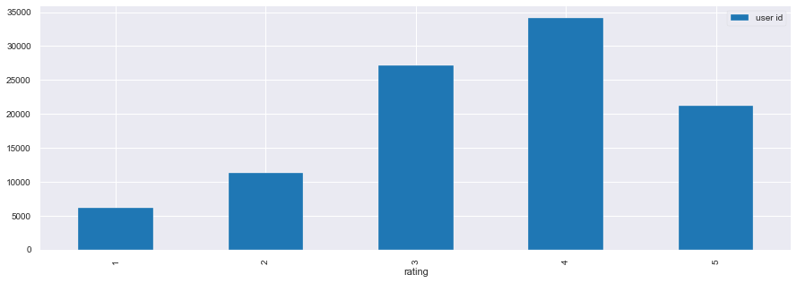

```python
user_movies_ratings_pd.groupby(by=['rating']).count().reset_index().plot(x='rating',y='user id',kind='bar',figsize=(15,5))
plt.show()
```

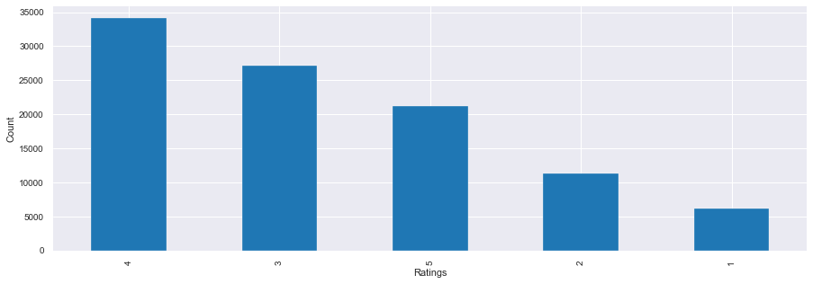

```python
ax = user_movies_ratings_pd['rating'].value_counts().plot(x='rating',kind='bar',figsize=(15,5))
ax.set_xlabel("Ratings")
ax.set_ylabel("Count")
plt.show()
```

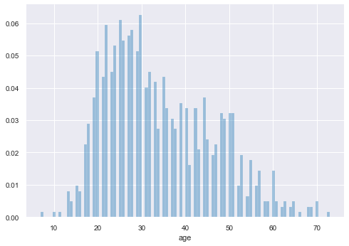

```python
sns.distplot(user_pd['age'], kde=False, norm_hist=True, bins=100)
```

[figure not shown]

```python
#sns.lineplot(data=movie_details_pd['release date'])
plt.figure(figsize=(100,50))

sns.countplot(x="release year", data=movie_details_pd)
```

```python
user_pd.head()
```

|  | user id | age | gender | occupation | zip code |
| --- | --- | --- | --- | --- | --- |
| 0 | 1 | 24 | M | technician | 85711 |
| 1 | 2 | 53 | F | other | 94043 |
| 2 | 3 | 23 | M | writer | 32067 |
| 3 | 4 | 24 | M | technician | 43537 |
| 4 | 5 | 33 | F | other | 15213 |

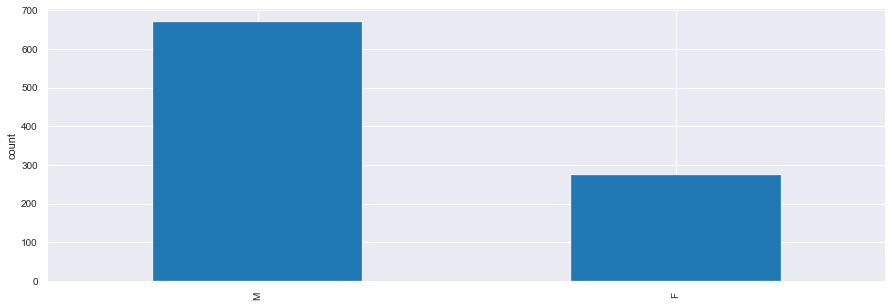

```python
#'Gender' and 'Occupation'
#sns.barplot(x='gender',  data=user_pd)
ax = user_pd['gender'].value_counts().plot(x='gender',kind='bar',figsize=(15,5))
ax.set_ylabel("count")
plt.show()
```

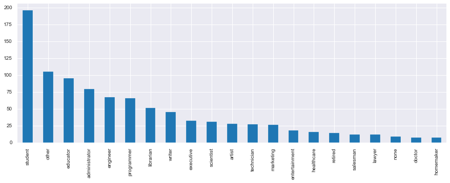

```python
user_pd['occupation'].value_counts().plot(x='occupation',kind='bar',figsize=(15,5))
plt.show()
```

### 8. Visualize how popularity of genres has changed over the years - 10 marks

Note that you need to use the **percent of number of releases in a year** as a parameter of popularity of a genre

Hint 1: You need to reach to a data frame where the release year is the index and the genre is the column names (one cell shows the number of release in a year in one genre) or vice versa. (Drop unnecessary column if there are any)

Hint 2: Find the total number of movies release in a year(use `sum(axis=1)` store that value in a new column as 'total'). Now divide the value of each genre in that year by total to get percentage number of release in a particular year. `(df.div(df['total'], axis= 0) * 100)`

Once that is achieved, you can either use univariate plots or can use the heatmap to visualise all the changes over the years in one go.

Hint 3: Use groupby on the relevant column and use sum() on the same to find out the number of releases in a year/genre.

```python
pprint.pprint(user_movies_ratings_pd.head())
pprint.pprint(movie_details_pd.head())
pprint.pprint(user_pd.head())
```

```
   user id  movie id  rating  timestamp
0      196       242       3  881250949
1      186       302       3  891717742
2       22       377       1  878887116
3      244        51       2  880606923
4      166       346       1  886397596
   movie id  movie title release date  unknown  Action  Adventure  Animation  \
0         1   Toy Story    1995-01-01        0       0          0          1
1         2   GoldenEye    1995-01-01        0       1          1          0
2         3  Four Rooms    1995-01-01        0       0          0          0
3         4  Get Shorty    1995-01-01        0       1          0          0
4         5     Copycat    1995-01-01        0       0          0          0

   Childrens  Comedy  Crime  ...  Film-Noir  Horror  Musical  Mystery  \
0          1       1      0  ...          0       0        0        0
```

[output cut: 19 more lines]

```python
user_movies_ratings_pd_sub = user_movies_ratings_pd[['movie id','rating']].groupby(['movie id']).sum()
```

```python
movie_details_pd.columns
```

```
Index(['movie id', 'movie title', 'release date', 'unknown', 'Action',
       'Adventure', 'Animation', 'Childrens', 'Comedy', 'Crime', 'Documentary',
       'Drama', 'Fantasy', 'Film-Noir', 'Horror', 'Musical', 'Mystery',
       'Romance', 'Sci-Fi', 'Thriller', 'War', 'Western', 'release year'],
      dtype='object')
```

```python
movie_details_pd_sub= movie_details_pd[['movie id', 'movie title', 'release date', 'unknown', 'Action',
       'Adventure', 'Animation', 'Childrens', 'Comedy', 'Crime', 'Documentary',
       'Drama', 'Fantasy', 'Film-Noir', 'Horror', 'Musical', 'Mystery',
       'Romance', 'Sci-Fi', 'Thriller', 'War', 'Western', 'release year']]

combinedByYear = pd.merge(user_movies_ratings_pd_sub,movie_details_pd_sub,on=['movie id'])


combinedByYear_sub_byGenre = combinedByYear[['release year','rating','unknown', 'Action',
       'Adventure', 'Animation', 'Childrens', 'Comedy', 'Crime', 'Documentary',
       'Drama', 'Fantasy', 'Film-Noir', 'Horror', 'Musical', 'Mystery',
       'Romance', 'Sci-Fi', 'Thriller', 'War', 'Western']].groupby(['release year']).sum()
```

```python
combinedByYear_sub_byGenre_counts = combinedByYear[['release year','rating','unknown', 'Action',
       'Adventure', 'Animation', 'Childrens', 'Comedy', 'Crime', 'Documentary',
       'Drama', 'Fantasy', 'Film-Noir', 'Horror', 'Musical', 'Mystery',
       'Romance', 'Sci-Fi', 'Thriller', 'War', 'Western']].groupby(['release year']).size().reset_index(name='counts')

combinedByYear_sub_byGenre_counts_final= result = pd.merge(combinedByYear_sub_byGenre, combinedByYear_sub_byGenre_counts, on=['release year'])
```

```python
combinedByYear_sub_byGenre_counts_final

percentageValues_sub = (combinedByYear_sub_byGenre_counts_final[['unknown', 'Action',
       'Adventure', 'Animation', 'Childrens', 'Comedy', 'Crime', 'Documentary',
       'Drama', 'Fantasy', 'Film-Noir', 'Horror', 'Musical', 'Mystery',
       'Romance', 'Sci-Fi', 'Thriller', 'War', 'Western']].div(combinedByYear_sub_byGenre_counts_final['counts'], axis= 0) * 100)

combinedByYear_sub_byGenre_counts_final_final = pd.concat( [combinedByYear_sub_byGenre_counts_final[['release year']], percentageValues_sub], axis=1)
```

```python
combinedByYear_sub_byGenre_counts_final_final
```

|  | release year | unknown | Action | Adventure | Animation | Childrens | Comedy | Crime | Documentary | Drama | Fantasy | Film-Noir | Horror | Musical | Mystery | Romance | Sci-Fi | Thriller | War | Western |
| --- | --- | --- | --- | --- | --- | --- | --- | --- | --- | --- | --- | --- | --- | --- | --- | --- | --- | --- | --- | --- |
| 0 | 1922 | 0.0 | 0.000000 | 0.000000 | 0.000000 | 0.000000 | 0.000000 | 0.000000 | 0.000000 | 0.000000 | 0.000000 | 0.000000 | 100.000000 | 0.000000 | 0.000000 | 0.000000 | 0.000000 | 0.000000 | 0.000000 | 0.000000 |
| 1 | 1926 | 0.0 | 0.000000 | 0.000000 | 0.000000 | 0.000000 | 0.000000 | 0.000000 | 0.000000 | 100.000000 | 0.000000 | 0.000000 | 0.000000 | 0.000000 | 0.000000 | 0.000000 | 0.000000 | 0.000000 | 0.000000 | 0.000000 |
| 2 | 1930 | 0.0 | 0.000000 | 0.000000 | 0.000000 | 0.000000 | 0.000000 | 0.000000 | 0.000000 | 100.000000 | 0.000000 | 0.000000 | 0.000000 | 0.000000 | 0.000000 | 0.000000 | 0.000000 | 0.000000 | 0.000000 | 0.000000 |
| 3 | 1931 | 0.0 | 0.000000 | 0.000000 | 0.000000 | 0.000000 | 0.000000 | 100.000000 | 0.000000 | 0.000000 | 0.000000 | 100.000000 | 0.000000 | 0.000000 | 0.000000 | 0.000000 | 0.000000 | 100.000000 | 0.000000 | 0.000000 |
| 4 | 1932 | 0.0 | 0.000000 | 0.000000 | 0.000000 | 0.000000 | 0.000000 | 0.000000 | 0.000000 | 0.000000 | 0.000000 | 0.000000 | 0.000000 | 0.000000 | 0.000000 | 100.000000 | 0.000000 | 0.000000 | 100.000000 | 0.000000 |
| ... | ... | ... | ... | ... | ... | ... | ... | ... | ... | ... | ... | ... | ... | ... | ... | ... | ... | ... | ... | ... |
| 66 | 1994 | 0.0 | 14.018692 | 6.074766 | 1.869159 | 7.009346 | 38.317757 | 3.738318 | 4.205607 | 45.327103 | 1.401869 | 0.000000 | 3.738318 | 0.934579 | 0.934579 | 16.355140 | 3.271028 | 11.682243 | 3.271028 | 2.803738 |
| 67 | 1995 | 0.0 | 18.264840 | 10.045662 | 2.739726 | 9.589041 | 28.767123 | 5.022831 | 2.283105 | 40.639269 | 1.369863 | 0.456621 | 6.392694 | 1.369863 | 2.283105 | 16.894977 | 6.849315 | 17.808219 | 2.283105 | 0.913242 |
| 68 | 1996 | 0.0 | 12.394366 | 6.760563 | 2.535211 | 5.915493 | 30.422535 | 5.915493 | 5.070423 | 47.887324 | 1.690141 | 0.281690 | 3.098592 | 2.535211 | 1.690141 | 10.704225 | 4.225352 | 13.239437 | 2.535211 | 0.563380 |
| 69 | 1997 | 0.0 | 16.083916 | 6.993007 | 1.048951 | 7.692308 | 30.419580 | 10.489510 | 2.097902 | 39.510490 | 1.398601 | 0.699301 | 2.797203 | 1.748252 | 6.293706 | 17.832168 | 4.545455 | 18.881119 | 4.895105 | 0.000000 |
| 70 | 1998 | 0.0 | 18.461538 | 4.615385 | 0.000000 | 1.538462 | 20.000000 | 10.769231 | 4.615385 | 50.769231 | 1.538462 | 3.076923 | 6.153846 | 1.538462 | 4.615385 | 16.923077 | 7.692308 | 27.692308 | 0.000000 | 0.000000 |

71 rows × 20 columns

[figure not shown]

```python
g = sns.PairGrid(combinedByYear_sub_byGenre_counts_final_final,x_vars='release year',y_vars=['unknown', 'Action',
       'Adventure', 'Animation', 'Childrens', 'Comedy', 'Crime', 'Documentary',
       'Drama', 'Fantasy', 'Film-Noir', 'Horror', 'Musical', 'Mystery',
       'Romance', 'Sci-Fi', 'Thriller', 'War', 'Western'])
g = g.map(plt.plot)
```

### 9. Find the top 25 movies according to average ratings such that each movie has number of ratings more than 100 - 10 marks

Hints :

1. Find the count of ratings and average ratings for every movie.
2. Slice the movies which have ratings more than 100.
3. Sort values according to average rating such that movie which highest rating is on top.
4. Select top 25 movies.
5. You will have to use the .merge() function to get the movie titles.

Note: This question will need you to research about groupby and apply your findings. You can find more on groupby on https://realpython.com/pandas-groupby/.

```python
combinedByYear
```

|  | movie id | rating | movie title | release date | unknown | Action | Adventure | Animation | Childrens | Comedy | ... | Film-Noir | Horror | Musical | Mystery | Romance | Sci-Fi | Thriller | War | Western | release year |
| --- | --- | --- | --- | --- | --- | --- | --- | --- | --- | --- | --- | --- | --- | --- | --- | --- | --- | --- | --- | --- | --- |
| 0 | 1 | 1753 | Toy Story | 1995-01-01 | 0 | 0 | 0 | 1 | 1 | 1 | ... | 0 | 0 | 0 | 0 | 0 | 0 | 0 | 0 | 0 | 1995 |
| 1 | 2 | 420 | GoldenEye | 1995-01-01 | 0 | 1 | 1 | 0 | 0 | 0 | ... | 0 | 0 | 0 | 0 | 0 | 0 | 1 | 0 | 0 | 1995 |
| 2 | 3 | 273 | Four Rooms | 1995-01-01 | 0 | 0 | 0 | 0 | 0 | 0 | ... | 0 | 0 | 0 | 0 | 0 | 0 | 1 | 0 | 0 | 1995 |
| 3 | 4 | 742 | Get Shorty | 1995-01-01 | 0 | 1 | 0 | 0 | 0 | 1 | ... | 0 | 0 | 0 | 0 | 0 | 0 | 0 | 0 | 0 | 1995 |
| 4 | 5 | 284 | Copycat | 1995-01-01 | 0 | 0 | 0 | 0 | 0 | 0 | ... | 0 | 0 | 0 | 0 | 0 | 0 | 1 | 0 | 0 | 1995 |
| ... | ... | ... | ... | ... | ... | ... | ... | ... | ... | ... | ... | ... | ... | ... | ... | ... | ... | ... | ... | ... | ... |
| 1675 | 1678 | 1 | Mat' i syn | 1998-02-06 | 0 | 0 | 0 | 0 | 0 | 0 | ... | 0 | 0 | 0 | 0 | 0 | 0 | 0 | 0 | 0 | 1998 |
| 1676 | 1679 | 3 | B. Monkey | 1998-02-06 | 0 | 0 | 0 | 0 | 0 | 0 | ... | 0 | 0 | 0 | 0 | 1 | 0 | 1 | 0 | 0 | 1998 |
| 1677 | 1680 | 2 | Sliding Doors | 1998-01-01 | 0 | 0 | 0 | 0 | 0 | 0 | ... | 0 | 0 | 0 | 0 | 1 | 0 | 0 | 0 | 0 | 1998 |
| 1678 | 1681 | 3 | You So Crazy | 1994-01-01 | 0 | 0 | 0 | 0 | 0 | 1 | ... | 0 | 0 | 0 | 0 | 0 | 0 | 0 | 0 | 0 | 1994 |
| 1679 | 1682 | 3 | Scream of Stone (Schrei aus Stein) | 1996-03-08 | 0 | 0 | 0 | 0 | 0 | 0 | ... | 0 | 0 | 0 | 0 | 0 | 0 | 0 | 0 | 0 | 1996 |

1680 rows × 24 columns

```python
user_movies_ratings_pd_withCounts = user_movies_ratings_pd[['movie id','rating']].groupby(['movie id']).size().reset_index(name='counts')
```

```python
combinedByRatings = pd.merge(user_movies_ratings_pd_withCounts,movie_details_pd_sub,on=['movie id'])
combinedByRatingsSumCounts = pd.merge(combinedByRatings,user_movies_ratings_pd[['movie id','rating']].groupby(['movie id']).sum(),on=['movie id'])[['movie id','rating','counts','movie title']]
```

```python
combinedByRatingsSumCounts
```

|  | movie id | rating | counts | movie title |
| --- | --- | --- | --- | --- |
| 0 | 1 | 1753 | 452 | Toy Story |
| 1 | 2 | 420 | 131 | GoldenEye |
| 2 | 3 | 273 | 90 | Four Rooms |
| 3 | 4 | 742 | 209 | Get Shorty |
| 4 | 5 | 284 | 86 | Copycat |
| ... | ... | ... | ... | ... |
| 1675 | 1678 | 1 | 1 | Mat' i syn |
| 1676 | 1679 | 3 | 1 | B. Monkey |
| 1677 | 1680 | 2 | 1 | Sliding Doors |
| 1678 | 1681 | 3 | 1 | You So Crazy |
| 1679 | 1682 | 3 | 1 | Scream of Stone (Schrei aus Stein) |

1680 rows × 4 columns

```python
moviesWithMoreThan100Ratings = combinedByRatingsSumCounts.loc[combinedByRatingsSumCounts['counts'] > 100].reset_index()
moviesWithMoreThan100Ratings['averageRatings']=moviesWithMoreThan100Ratings['rating']/moviesWithMoreThan100Ratings['counts']
moviesWithMoreThan100Ratings.sort_values(['averageRatings'], ascending=[False]).reset_index()[['averageRatings','movie title']].head(25)
```

|  | averageRatings | movie title |
| --- | --- | --- |
| 0 | 4.491071 | Close Shave, A |
| 1 | 4.466443 | Schindler's List |
| 2 | 4.466102 | Wrong Trousers, The |
| 3 | 4.456790 | Casablanca |
| 4 | 4.445230 | Shawshank Redemption, The |
| 5 | 4.387560 | Rear Window |
| 6 | 4.385768 | Usual Suspects, The |
| 7 | 4.358491 | Star Wars |
| 8 | 4.344000 | 12 Angry Men |
| 9 | 4.292929 | Citizen Kane |
| 10 | 4.292237 | To Kill a Mockingbird |
| 11 | 4.291667 | One Flew Over the Cuckoo's Nest |
| 12 | 4.289744 | Silence of the Lambs, The |
| 13 | 4.284916 | North by Northwest |
| 14 | 4.283293 | Godfather, The |
| 15 | 4.265432 | Secrets & Lies |
| 16 | 4.262626 | Good Will Hunting |
| 17 | 4.259542 | Manchurian Candidate, The |
| 18 | 4.252577 | Dr. Strangelove or: How I Learned to Stop Worr... |
| 19 | 4.252381 | Raiders of the Lost Ark |
| 20 | 4.251397 | Vertigo |
| 21 | 4.245714 | Titanic |
| 22 | 4.231214 | Lawrence of Arabia |
| 23 | 4.210145 | Maltese Falcon, The |
| 24 | 4.204360 | Empire Strikes Back, The |